# esm206_lab10

Abigail Sanford

11/29/2021

## beepr::beep()

Beepr beeps: i.e. after the code is running it will give a beep sound

In the console you can write `beep(insert_#_btwn_1-12)` and get a preset sound!

beep(1) beep(2) beep(3) beep(4) beep(5)

Use `beep()` to give yourself an audio alert.

## Write a `for loop + beep`

```r
for(i in rev(seq(1:9999))){print(paste(i, "bottles of beer on the wall"))}

beep(4) # if you don't want this to make a sound when you knit it, make sure to do eval = FALSE in the setup
```

the reverse `rev` and sequence `seq` functions will give us a sequence that will count backwards between the two numbers we tell it.

For each of these elements, we want it to print out a line from the song. we use `print(i)` to do that. and if we want additional text to be written, we can use `paste(i, "insert what you want written after the sequence here")`

## `praise` is nice

```r
praise("${EXCLAMATION}!!! This code works ${adverb_manner}!") # this is case sensitive. So if its all in caps, then it will follow that caps in the output.
```

```
## [1] "MMH!!! This code works happily!"
```

```r
praise("Holy ${creating}, Batman - this code works ${ADVERB_MANNER}!")
```

```
## [1] "Holy inventing, Batman - this code works EAGERLY!"
```

## `cowsay::say` to have animals say something

```r
say("I love tacos!") # default is cat
```

```
##
##  --------------
## I love tacos!
##  --------------
##     \
##       \
##         \
##             |\___/|
##           ==) ^Y^ (==
##             \  ^  /
##              )=*=(
##             /     \
##             |     |
##            /| | | |\
##            \| | |_|/\
##       jgs  //_// ___/
##                \_)
##
```

```r
say("I love tacos!", by = "shark")
```

```
##
##  --------------
## I love tacos!
##  --------------
##     \
##       \
##         \
##               /""-._
##               .       '-,
##                :          '',
##                 ;      *     '.
##                  ' *         () '.
##                    \               \
##                     \      _.---.._ '.
##                     :  .' _.--''-''  \ ,'
##         .._           '/.'             . ;
##         ; `-.          ,                \'
##          ;   `,         ;              ._\
##           ;    \     _,-'                ''--._
##           :    \_,-'                          '-._
##           \ ,-'                       .          '-._
##           .'         __.-'';            \...,__       '.
##         .'      _,-'        \              \   ''--.,__  '\
##         /    _,--' ;         \              ;           \^.}
##         ;_,-' )     \  )\      )            ;
##              /       \/  \_.,-'             ;
##             /                              ;
##          ,-'  _,-'''-.    ,-.,            ;      PFA
##       ,-' _.-'        \  /    |/'-._...--'
##      :--``             )/
##   '
##
```

```r
say("I love tacos!", by = "trilobite")
```

````
##
##  --------------
## I love tacos!
##  --------------
##     \
##       \
##         \
##           _____
##        .'` ,-. `'.
##       /   ([ ])   \
##      /.-""`(`)`""-.\
##       <'```(.)```'>
##       <'```(.)```'>
##        <'``(.)``'>
##    sk   <``\_/``>
##          `'---'`
##
````

## `usethis` for everything

Can be used to update your r profile, and change what will show up everytime you start a new r session.

If we make an Rproject first, and then we want to make it version controlled we do the following:

R Project first, then git and GitHub repo

- usethis::use_git()
- usethis::use_github()

The above are the two steps we need to do. Make sure to write this code in the console because we only need to do this once.

In the console put `usethis::use_git()`. Then say that you want to commit, and that its ok to restart r.

Then put this into the console `usethis::use_github()`. Say `yeah` when it asks if you want to proceed (just put the number that is located next to the option it gives you and hit enter).

Change the name of a main branch in git hub: - click `1 branch` - click the pen next to the branch name. - Rename the branch to `main` or whatever you want - Click the name of the repo - A pop up will tell you which code you need to put into the Rstudio terminal in the bottom left box (you can just copy and paste it). - then in the git tab in the top right box, hit the refresh button. You should see the renamed branch name now.

## `paletteer`: aggregated color palettes

In console put this: `view(palettes_d_names)`. It will show you all the different color palettes available.

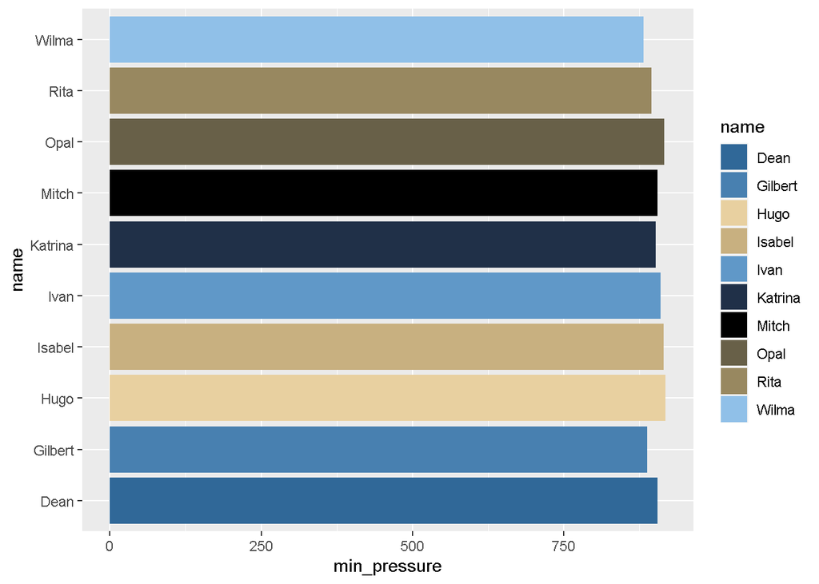

```r
storms %>% # default data set in dplyr
  group_by(name) %>%
  summarize(min_pressure = min(pressure, na.rm = TRUE)) %>% # minimum pressure for each storm
  slice_min (n = 10, min_pressure) %>% # bottom 10 values in dataset
  ggplot(aes(x = min_pressure, y = name)) +
  geom_col(aes(fill = name)) +# change the colomn color based on name. It will give the default color scheme.
  scale_fill_paletteer_d("palettetown::wailmer") # use paletter to access a different color palette. Give it the palette name with `"pkg::palette" like "beyonce::X116"
```

In the console, you can write `paletteer_d("palettetown::volbeat")` (with the pkg_name::palette_name) to get the hexidecimal codes of the colors. Then you can take the color you like and input it with `fill = #E05060FF` in your ggplot.

## Map of Jornada LTER Vegetation

If you have other file types, people have built other packages to read in the file types. Use google to find them.

- You can use `read_sf` for .kml files

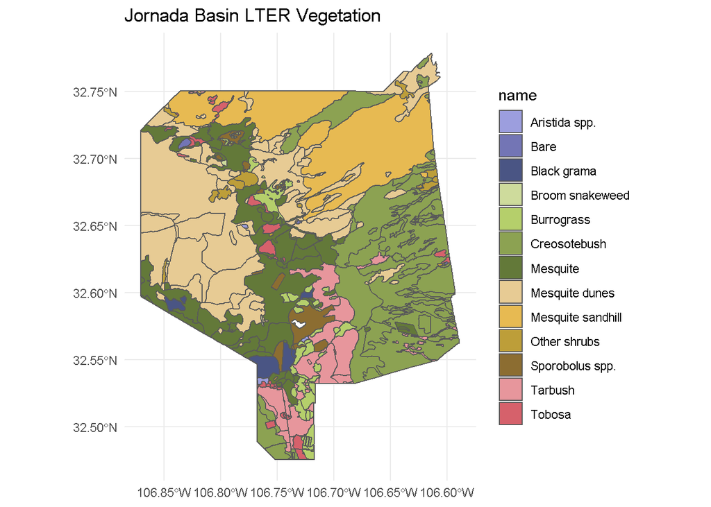

```r
jornada_veg <- read_sf("doc.kml") %>%
  select(Name) %>%
  clean_names()

ggplot() +
  geom_sf(data = jornada_veg, (aes(fill = name))) + # make a map of the data
  scale_fill_paletteer_d("ggthemes::manyeys") + #customize the color palate (this one is good for vegetation mapping)
  theme_minimal() + # Change the theme
  labs(title = "Jornada Basin LTER Vegetation")
```

```r
# Update this map:
# Each vegetation type has a different fill color
# Update the theme
# Customize the color palette

#If you want to share just the image of the plot with someone:

ggsave(filename = "my_awesome_jornada_map.png", width = 8, height = 5) # you will see a png file pop up in your files, that you can share with people. It's cool! It has a transparent background.
```

When we open the .kml file, we can see the discrete zones of dominant vegetation. Rstudio will assume that we want to retain the geometry (polygon) information when we are working with the data like it’s a normal data frame and we don’t have to worry about it as we play with it.

Then we can create a map with ggplot

how to color multiple things the same color, like if you wanted all the plants to be one color and the animals to be another. You can do this with google.